# 3 FAIR-Prinzipien berücksichtigen

Die FAIR-Prinzipien sind Richtlinien für die Speicherung und Veröffentlichung wissenschaftlicher Daten. Einen guten Einstieg bieten „Data models to GO-FAIR“ (2017) und Wilkinson u. a. (2016).

Daten sollen auffindbar, zugänglich, interoperabel und wiederverwertbar sein. Diese vier Eigenschaften werden häufig auf 15 [FAIR-Prinzipien](https://forschungsdaten.info/themen/veroeffentlichen-und-archivieren/faire-daten/) abgebildet. Auf der Ebene der vier grundlegenden Eigenschaften bietet Ihnen dieses Kapitel aber einen ersten Einstieg.

**Hinweis**

In Kapitel 7.6 finden Sie eine Checkliste der 15 FAIR-Prinzipien in einfachem [Markdown-Textormat](https://www.markdownguide.org/basic-syntax/).

## 3.1 Findable: DOI, Metadaten und Suchmaschinenoptimierung

Unsere Forschungsdaten und Softwareprojekte erstellen und pflegen wir häufig mit speziellen Softwarewerkzeugen. Dabei generieren wir schon vor der Veröffentlichung fortwährend Metadaten. Diese sind üblicherweise eher technischer Natur und gern in werkzeugspezifischen Konfigurationsdateien verstreut.

- Dann haben wir für jedes mit [GitHub](https://github.com) verwaltete Projekt eine README-Datei erstellt, die weitere Informationen über unser Projekt enthält (Kapitel 1).
- Dann haben wir unsere Projekte in [Zenodo](https://zenodo.org) integriert und müssen auch dort Informationen ergänzen (Kapitel 1).

Letztendlich wollen wir, dass unsere Forschungsdaten oder Softwareprojekte als Produkte eines Forschungsprozesses gefunden werden können. Dazu müssen wir sicher stellen, dass **produktrelevante Metadaten** in einem **standardisierten Format** vorliegen. Das ist mit Zenodo aber leichter, als es zunächst den Anschein hat, die Arbeit ist im Grunde schon erledigt.

### 3.1.1 DOI und Metadaten ergänzen

Prüfen Sie folgende Punkte, um die Auffindbarkeit der Daten zu verbessern:

Zenodo übernimmt für Sie neben der Vergabe eines digitalen Objektbezeichners (DOI, siehe auch *DOI Handbook* (2023)) auch die Generierung von standardisierten Metadaten. Data Cite und Dublin Core können dann direkt aus Zenodo abgefragt werden, beispielsweise über die Exportfunktion (unten rechts in Abbildung 3.1).

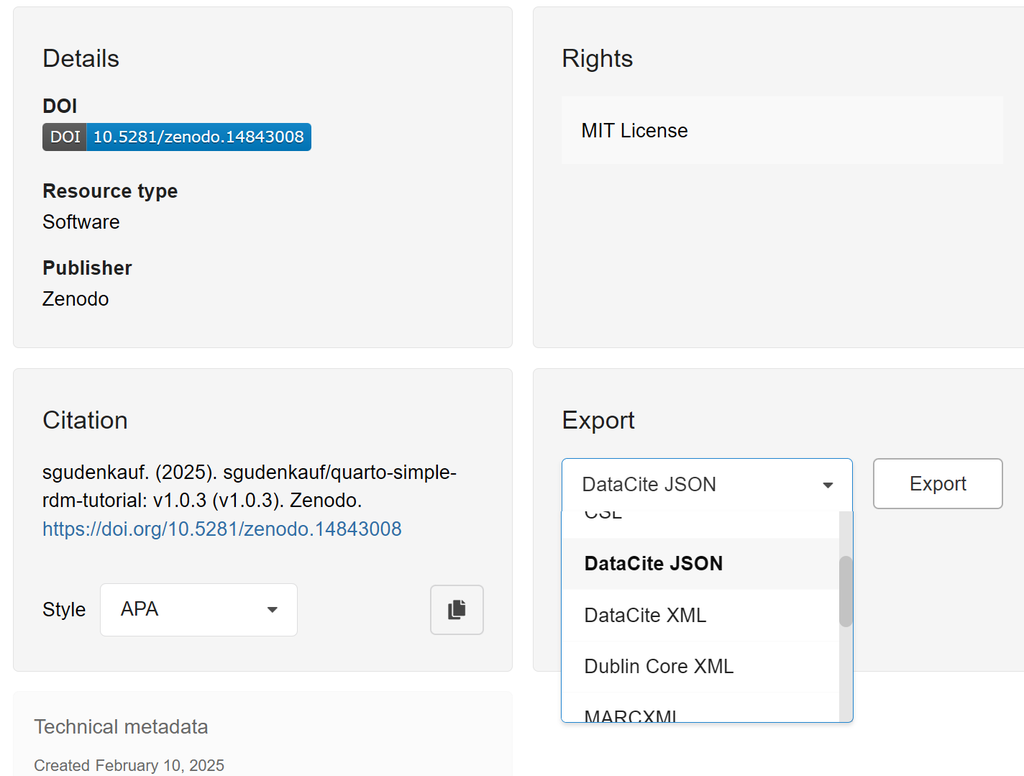

Abbildung 3.1: Export von Metadaten aus Zenodo.

**Hinweis**

In Kapitel 7.8 finden Sie die Metadaten zu diesem Dokument in den Formaten [DataCite JSON](https://schema.datacite.org/) und [Dublin Core XML](https://www.dublincore.org/).

**Ergänzen Sie bei Bedarf im DMP:**

```markdown
**Metadatenformat**:
- [z. B. DataCite, Dublin Core]

**Beschreibung der Daten**:
- Jede Datei wird durch eine README-Datei dokumentiert, die Informationen über:
   - Den Inhalt
   - Die Erhebungsmethodik
   - Verwendete Software oder Tools enthält.
- Schlagwörter: [Themenrelevante Begriffe, z. B. "Machine Learning", "Umweltdaten"]

**DOI-Zuweisung**:
- Die Veröffentlichung erfolgt mit einem DOI über Zenodo.
```

### 3.1.2 Suchmaschinen unterstützen

- GitHub-Projekte werden in der Regel von GitHub automatisch indexiert, so dass sie besser gefunden werden können.
- Zusätzlich sollten Sie keine unnötigen `.gitignore`-[Einstellungen](https://git-scm.com/book/en/v2/Git-Basics-Recording-Changes-to-the-Repository#_ignoring) in GitHub verwenden.

## 3.2 Accessible: Langfristige Zugänglichkeit sicherstellen

- Ergänzen Sie im Datenmanagementplan explizit Angaben zur langfristigen Speicherung über Zenodo und dass die Daten öffentlich zugänglich sind ([Open Access](https://de.wikipedia.org/wiki/Open_Access)).
- Zeitliche Einschränkungen des Zugriffs können über die den so genannten [Embargo-Status](https://about.zenodo.org/policies/) in Zenodo geregelt werden.

**Ergänzen Sie bei Bedarf im DMP:**

```markdown
**Zugänglichkeit**:
- Die Daten sind über Zenodo öffentlich zugänglich (Open Access).
- Der DOI garantiert die dauerhafte Verfügbarkeit.
- Einschränkungen: Einschränkungen des Zugriffs werden über Embargo-Status Optionen von Zenodo geregelt.
```

## 3.3 Interoperable: Datenformate und Standards beschreiben

- Verwenden Sie für Ihre Daten Dateiformate, die eine möglichst einfache maschinelle Verarbeitung erlauben.
  - Es bieten sich offene Formate wie z. B. CSV gemäß Hausenblas u. a. (2014) und JSON gemäß Charollais an.
  - Verzichten Sie auf proprietäre Formate wie z. B. Microsoft Excel (`.xlsx`-Dateien).
- Nennen Sie die verwendeten Standards für Daten und Metadaten wie z. B. [DataCite](https://schema.datacite.org/), [Dublin Core](https://www.dublincore.org/specifications/dublin-core/) oder [JSON-Schema](https://json-schema.org/).
- Nennen Sie Ontologien oder kontrollierte Vokabulare zur Standardisierung von Fachbegriffen, z. B. [MeSH](https://www.nlm.nih.gov/mesh/meshhome.html), [AGROVOC](https://www.fao.org/agrovoc/).

**Ergänzen Sie bei Bedarf im DMP:**

```markdown
**Interoperabilität:**
- Daten werden in offenen Formaten gespeichert (siehe Abschnitt 2, Arten und Umfang der Daten)
- Metadaten-Standards: DataCite für Beschreibung und DOI-Referenzierung
- Ontologien oder kontrollierte Vokabulare zur Standardisierung von Begriffen: Verwendung von [z. B. MeSH, AGROVOC]
```

## 3.4 Reusable: Dokumentation und Lizenzierung beschreiben

Ohne Angabe einer Lizenz können Ihre Daten nicht weiterverwendet werden. Weit verbreitet und üblich sind die Lizenz [CC-BY 4.0](https://creativecommons.org/licenses/by/4.0/) für Dokumente und die [MIT-Lizenz](https://opensource.org/license/mit) für ausführbaren Programmcode und Softwareprojekte.

Als recht freizügige Lizenz bietet die MIT-Lizenz ein geringes Risiko im Zusammenspiel mit anderen Lizenzen. Beispielsweise erlaubt sie die Wiederverwendung von Code in proprietärer Software. Creative-Commons-(CC)-Lizenzen sind dagegen nicht für die Nutzung in Software oder Hardware empfohlen (Bals (2024)).

Da Veröffentlichungen von Forschungsdaten häufig auch ausführbaren Code wie z.B. Python-Skripte beinhalten, bevorzugen wir im Zweifelsfall die MIT-Lizenz.

**Ergänzen Sie bei Bedarf im DMP:**

```markdown
**Wiederverwendbarkeit:**
- Lizenz: [z. B. MIT, erlaubt die Nachnutzung auch in proprietärer Software unter der Bedingung der Namensnennung]
- Vollständige Dokumentation der Daten: [Methoden, Kontext, verwendete Software wie z. B. Python-Skripte mit spezifischen Bibliotheksversionen]
- Anleitungen für die Nachnutzung: [z. B. siehe README-Datei]
```

## 3.5 README-Datei und Zugriff auf Metadaten

Falls Metadaten generiert werden, können Sie darauf auch in der README-Datei verweisen. Verwenden Sie Zenodo, genügt ein Verweis auf den DOI, der auf Zenodo verweist.

- Menschliche Nutzer können standardisierte Metadaten aus Zenodo exportieren (Abbildung 3.1).
- Der softwaretechnische Zugriff auf Metadaten kann mittels Python-Skripte über die [Zenodo-API](https://developers.zenodo.org) realisiert werden.

**Ergänzen Sie bei Bedarf in der README-Datei:**

```markdown
## Metadata
The dataset is described using the DataCite metadata schema. Key elements include:
- **Title**: Title of the dataset.
- **Author(s)**: Name(s) of the contributors.
- **Keywords**: Relevant keywords for discoverability.
- **Description**: Detailed dataset description, including methodology and tools.
- **License**: MIT
- **DOI**: [Zenodo DOI link].
```

[Data models to GO-FAIR](https://doi.org/10.1038/ng.3910). In: *Nature Genetics* Bd. 49 (2017), Nr. 7, S. 971–971

*[DOI Handbook](https://doi.org/10.1000/182)*, 2023

Bals, Fred: *[Top open source licenses and legal risk for developers](https://www.blackduck.com/blog/top-open-source-licenses.html)*, 2024

Charollais, Patrick: ECMA-404, 2nd edition, December 2017

Hausenblas, M. ; Wilde, E. ; Tennison, J.: *[URI Fragment Identifiers for the text/csv Media Type](https://doi.org/10.17487/rfc7111)* ( Nr. RFC7111) : RFC Editor, 2014

Wilkinson, Mark D. ; Dumontier, Michel ; Aalbersberg, IJsbrand Jan ; Appleton, Gabrielle ; Axton, Myles ; Baak, Arie ; Blomberg, Niklas ; Boiten, Jan-Willem ; u. a.: [The FAIR Guiding Principles for scientific data management and stewardship](https://doi.org/10.1038/sdata.2016.18). In: *Scientific Data* Bd. 3 (2016), Nr. 1, S. 160018